# EGARCH R实现

Yuzhi Liu

31 三月 2020

## 1.前期准备

## 1.1安装FinTS 程序包

$ wget http://labfile.oss.aliyuncs.com/courses/900/FinTS_0.4-5.tar.gz

## 1.2包载入

```r
library(fGarch)
library(rugarch)#garch拟合与预测
library(TSA)#BIC准则确定arma阶数  eacf确定garch阶数
library(tseries)
library(forecast)#auto.arima() arma阶数确定方法
library(psych)#数据描述统计分析
```

```r
library(ggplot2)#绘图
library(FinTS)#JB统计量
```

## 2.实验过程

## 2.1计算对数收益率

使用 diff 函数直接做差分求对数收益率

```r
setwd("C:/Users/10982/E-GARCH")
NSDK<-read.csv("NSDK.csv")
##计算对数收益率
dNSDK<-diff(log(NSDK$close))
head(dNSDK)
```

```
## [1] -0.034688738  0.011373518  0.011269905  0.009656441 -0.010407156
## [6] -0.014679366
```

## 2.2股票指数的可视化

对平稳化处理后的NSDK指数进行正态性检验

1.绘制数据分布函数，QQ图，对数收益率序列折线图

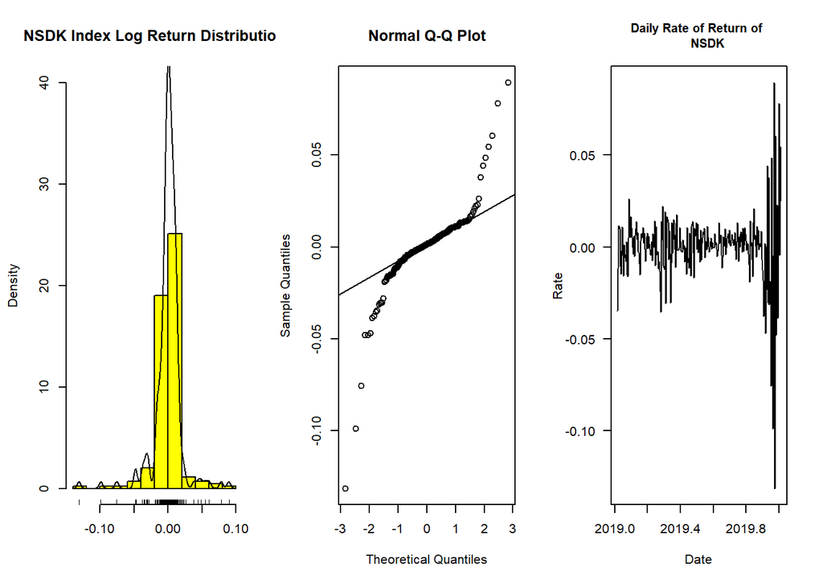

```r
par(mfrow=c(1,3),oma=c(0.2,0.2,0.2,0.2))
hist(dNSDK,main="NSDK Index Log Return Distribution",col="yellow",xlab="",ylim=c(0,40),probability=T)
lines(density(dNSDK),lwd=1);rug(dNSDK)#first graph
qqnorm(dNSDK);qqline(dNSDK)#second graph
dNSDK.ts<-ts(dNSDK,start=c(2019, 5 ,10),end=c(2020, 3 ,26),freq=222)
plot(dNSDK.ts,type="l",main=" Daily Rate of Return of
     NSDK",xlab="Date", ylab="Rate", cex.main=0.95, las=1)#third graph
```

分布为数据分布函数，QQ图，对数收益率序列点图。收益率分布图、QQ图可以看出 金融时间序列确实表现出尖峰厚尾性，相对于标准正态分布，峰度更高，两段的尾部更厚， 也就是极值更多。由收益率波动序列可以看出NSDK股票指数收益率序列在样本区间内均表现 出一定的波动性和聚集性，尤其在后半段波动性更为明显。

2.调用函数进行正态性检验

```r
jarque.bera.test(dNSDK)
```

```
##
##  Jarque Bera Test
##
## data:  dNSDK
## X-squared = 1532.9, df = 2, p-value < 2.2e-16
```

P越小越非正态，p-value < 2.2e-16 图形与函数都展示了数据的非正态性，二者结果一致。

## 2.3ACF 图和 PACF 图

用自相关函数（ACF）和偏自相关函数（PACF）来对收益率序列的自相关性进行分析。

1.用ggplot2作图

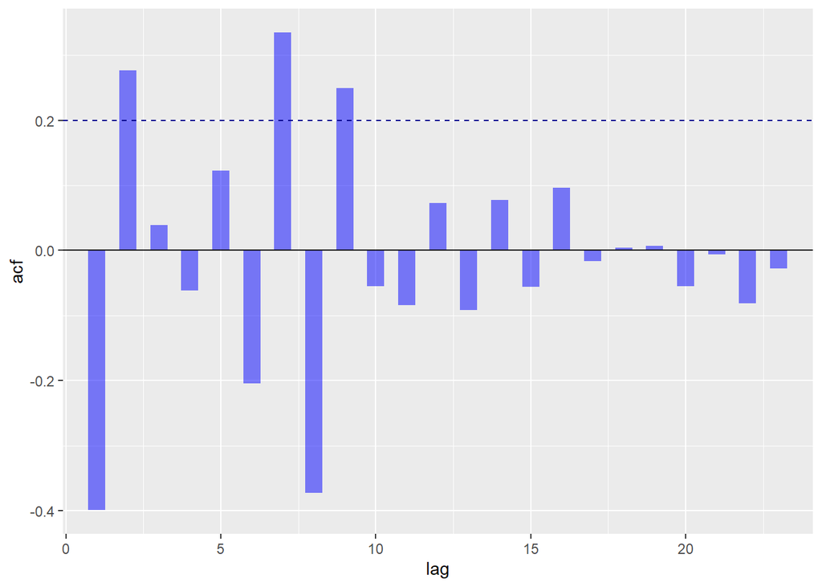

```r
#ACF
par(mfrow=c(2,1))
bacf <- acf(dNSDK, plot = FALSE)
bacfdf <- with(bacf, data.frame(lag, acf))
ggplot(data = bacfdf, mapping = aes(x = lag, y = acf)) +
  geom_segment(mapping = aes(xend = lag, yend = 0),color='blue',size=5,alpha=I(1/2)) +
  geom_hline(aes(yintercept = 0.2),linetype = 2, color = 'darkblue')+
  geom_hline(aes(yintercept=0))
```

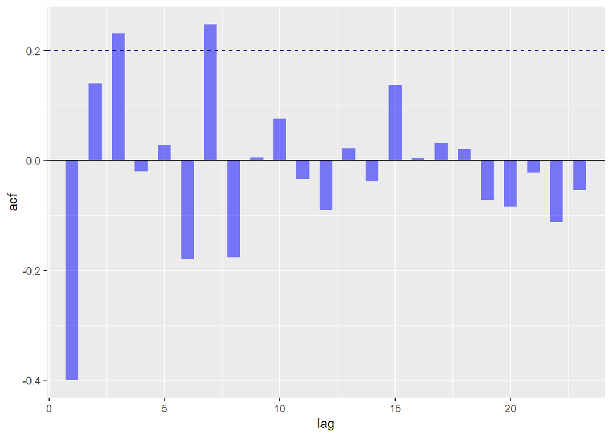

```r
# pacf
bpacf <- pacf(dNSDK, plot = FALSE)
bpacf <- with(bpacf, data.frame(lag, acf))
ggplot(data = bpacf, mapping = aes(x = lag, y = acf)) +
  geom_segment(mapping = aes(xend = lag, yend = 0),color='blue',size=5,alpha=I(1/2)) +
  geom_hline(aes(yintercept = 0.2), linetype = 2, color = 'darkblue')+
  geom_hline(aes(yintercept=0))
```

2.调用forecast函数作图

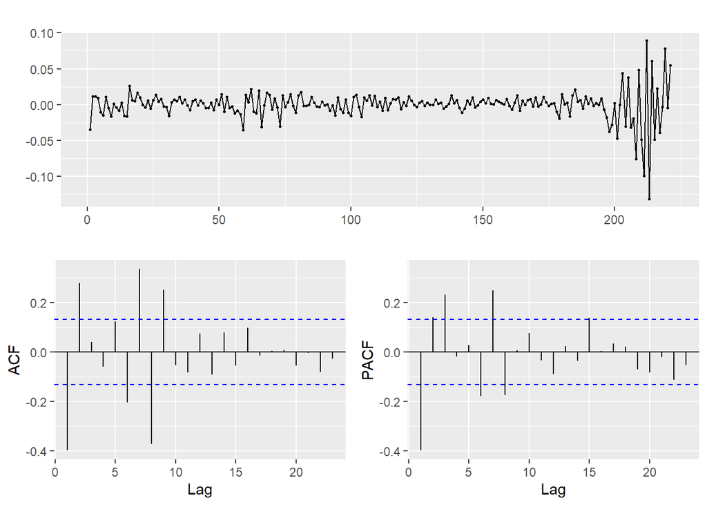

```r
library("forecast")
forecast::ggtsdisplay(dNSDK)
```

由 ACF 图和 PACF 图可以得出：两个图大部分函数值在置信区间内（图中蓝色虚线区域）上下跳跃,所以收益率序列自相关性很低,或者说具有很弱的自相关性，因此在条件期望模型中不需要引入自相关性部分，满足GARCH模型中的均值方程，收益率由一个常数项加上一个随机扰动项组成。

3.调用函数进行平稳性检验

```r
adf.test(dNSDK,alt="stationary")
```

```
##
##  Augmented Dickey-Fuller Test
##
## data:  dNSDK
## Dickey-Fuller = -3.9913, Lag order = 6, p-value = 0.01043
## alternative hypothesis: stationary
```

若 ADF p<0.05 认为序列是均值回归的,p-value = 0.01043<0.05,故数据是平稳的。

4.要拟合 GARCH 模型，我们还需要考察收益率平方的自相关性

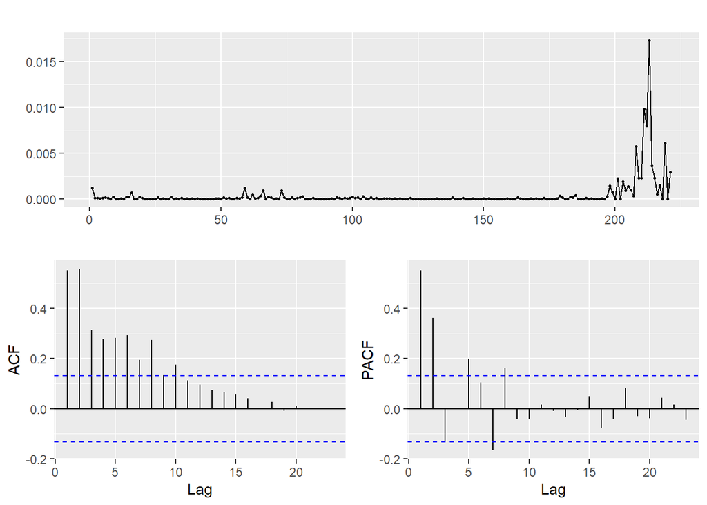

```r
library("forecast")
forecast::ggtsdisplay(dNSDK^2)
```

但NSDK收益率平方的ACF值表现出了一定的相关性和持续性，其大部分值都超过了置信区间 （图中蓝色虚线）。注意到NSDK收益率平方的ACF值在滞后10期后之后缓慢衰退, 说明了方差序列具有一定程度的序列相关性,因此采用 GARCH 模型来描述股价波动过程中的 条件方差。

## 2.4ARCH 效应的检验

收益率的时序图表明，在日收益率数据中可能存在ARCH效应，如果存在ARCH效应，则可以进行GARCH模型的拟合。反之，不能用 GARCH 模型拟合方程。

得先arima拟合模型，对残差进行LM检验

```r
armamodel=auto.arima(dNSDK)#自动基于AIC最小准则，寻找最佳拟合模型
armamodel
```

```
## Series: dNSDK
## ARIMA(1,0,2) with zero mean
##
## Coefficients:
##          ar1      ma1     ma2
##       0.0155  -0.4013  0.3997
## s.e.  0.1910   0.1769  0.0747
##
## sigma^2 estimated as 0.000324:  log likelihood=575.57
## AIC=-1143.14   AICc=-1142.96   BIC=-1129.55
```

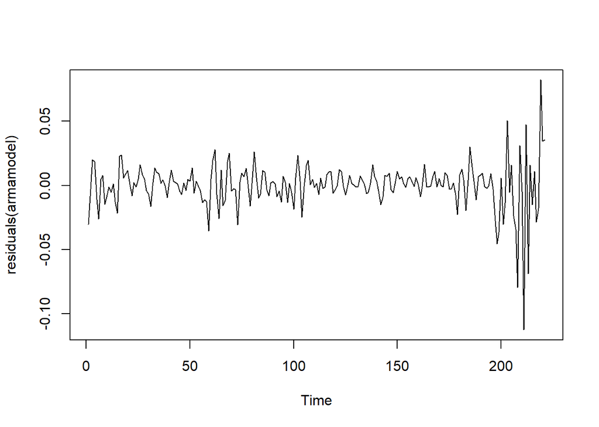

```r
plot(residuals(armamodel))
```

```r
par(mfrow=c(1,1))
lmresult=McLeod.Li.test(y=residuals(armamodel))#残差arch效应很显著
```

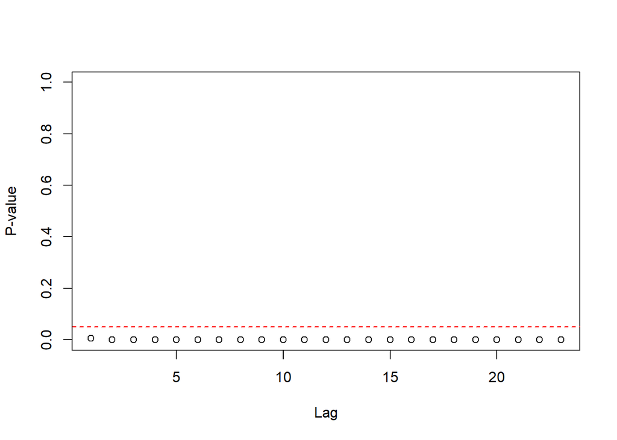

由图可知，残差序列滞后23阶后，残差自回归函数的系数显著，序列仍然存在自相关。因此 拒绝原假设，说明样本序列存在显著的ARCH效应。 综上，对数收益率序列具有波动聚集性，序列平稳，有显著ARCH效应。序列时候GARCH模型建模。

```r
ArchTest(dNSDK,lag=23)
```

```
##
##  ARCH LM-test; Null hypothesis: no ARCH effects
##
## data:  dNSDK
## Chi-squared = 131.79, df = 23, p-value < 2.2e-16
```

检验的原假设是：不存在 ARCH 效应。检验结果为卡方统计量的值为131.8，对应的 P 值几乎为0，也就是说在 1% 的显著性水平上拒绝原假设，从而拒绝不存在 ARCH 效应的假设， 收益率序列存在 ARCH 效应，可以进行 GARCH 模型的拟合。

## 2.5EGARCH 模型的估计

```r
myspec=ugarchspec(
  variance.model = list(model = "eGARCH", garchOrder = c(2, 1)),
  mean.model = list(armaOrder = c(0,0), include.mean = TRUE),
  distribution.model = "std"
)

myfit=ugarchfit(myspec,data=dNSDK,solver="gosolnp")
myfit
```

```
##
## *---------------------------------*
## *          GARCH Model Fit        *
## *---------------------------------*
##
## Conditional Variance Dynamics
## -----------------------------------
## GARCH Model  : eGARCH(2,1)
## Mean Model   : ARFIMA(0,0,0)
## Distribution : std
##
## Optimal Parameters
## ------------------------------------
##         Estimate  Std. Error     t value Pr(>|t|)
## mu      0.000437    0.000446  9.8023e-01 0.326975
## omega  -0.844318    0.031750 -2.6593e+01 0.000000
## alpha1 -0.562372    0.094241 -5.9673e+00 0.000000
## alpha2  0.119176    0.079569  1.4978e+00 0.134190
## beta1   0.907856    0.000002  5.1269e+05 0.000000
## gamma1  0.008736    0.161753  5.4010e-02 0.956927
## gamma2  0.329420    0.175687  1.8750e+00 0.060787
## shape  99.997611   12.708982  7.8683e+00 0.000000
##
## Robust Standard Errors:
##         Estimate  Std. Error     t value Pr(>|t|)
## mu      0.000437    0.000387  1.1287e+00 0.259035
## omega  -0.844318    0.032626 -2.5879e+01 0.000000
## alpha1 -0.562372    0.084138 -6.6839e+00 0.000000
## alpha2  0.119176    0.081700  1.4587e+00 0.144648
## beta1   0.907856    0.000000  2.9978e+06 0.000000
## gamma1  0.008736    0.137955  6.3327e-02 0.949506
## gamma2  0.329420    0.186466  1.7667e+00 0.077286
## shape  99.997611    9.450153  1.0582e+01 0.000000
##
## LogLikelihood : 694.9545
##
## Information Criteria
## ------------------------------------
##
## Akaike       -6.2168
```

[output cut: 49 more lines]

```
## Negative Sign Bias  0.5329 0.5947
## Positive Sign Bias  2.3573 0.0193  **
## Joint Effect        5.8708 0.1181
##
##
## Adjusted Pearson Goodness-of-Fit Test:
## ------------------------------------
##   group statistic p-value(g-1)
## 1    20     17.10       0.5831
## 2    30     35.15       0.1995
## 3    40     46.69       0.1857
## 4    50     51.17       0.3884
##
##
## Elapsed time : 2.430609
```